# Fourier Transforms

A means to describe waveforms as sinusoidal sums.

## Introduction

What is a sinusoid ? A sine wave. What is sine ? It is what we know from trigonometry.

```python
import matplotlib.pyplot as plt
# conda install -c conda-forge matplotlib
import math
```

Here is a sine wave.

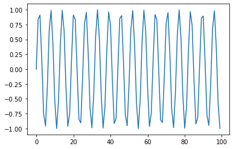

```python
xvals = []
yvals = []
for i in range(100):
    xvals.append(i)
    yvals.append(math.sin(i))

plt.plot(xvals, yvals)
```

Let's make it a function.

```python
def sinplot(sample_nb: int):
    xvals = []
    yvals = []
    for i in range(sample_nb):
        xvals.append(i)
        yvals.append(math.sin(i))

    plt.plot(xvals, yvals, xvals, [0 for i in range(len(xvals))])
```

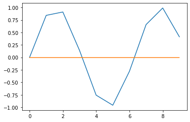

```python
sinplot(10)
```

```python
sinplot(100)
```

[output not shown]

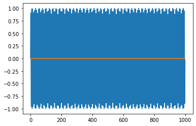

```python
sinplot(1000)
```

The above demonstration should make it clear, that the frequency of sine waves can help us to describe different shapes. Notice that it is periodic, since $sin(x) = sin(x+2\pi)$ where $x \in \mathbb{R}$

In its most basic form a sine wave can be described as a function of time as in $$y(x) = a\sin k(x + \beta)$$

We shall see what each element does as we advance

Let's implement this.

```python
def sinfn(a,k, beta, t): return a*math.sin(k*(t+beta))

def sinmap(a,k,beta,sample_nb, fn=sinfn):
    xvals=list(range(sample_nb))
    yvals=[fn(a,k,beta,i) for i in xvals]
    return xvals, yvals

def sinMultiMap(amps: [int],
                periods: [int],
                shifts: [int],
                sample_nb,
                fns: list):
    if (any([a <= 0 for a  in amps]) or
        any([k <=0 for k in periods])):
        raise ValueError("all amps and shifts must be positive")
    lst = []
    for i in range(len(amps)):
        a = amps[i]
        k = periods[i]
        beta = shifts[i]
        fn = fns[i]
        xs, ys = sinmap(a,k,beta, sample_nb, fn)
        lst.append(xs)
        lst.append(ys)
    return lst


def sinwave_plot(a,k,beta, sample_nb, fn=sinfn):
    if a <= 0 or k <= 0:
        raise ValueError("a and k must be positive")
    xvals, yvals = sinmap(a,k,beta,sample_nb, fn)
    plt.plot(xvals, yvals, xvals, [0 for i in range(len(xvals))])
```

```python
sinwave_plot(a=1,k=1,beta=0,sample_nb=100) # sin(x)
```

[output not shown]

As we have stated the sin function is periodic. A period is formally defined as: The period of a periodic function f(x) is the smallest positive real number p such that f(x+p) = f(x) for all values of x for which f(x) and f(x+p) are defined (Saul 2001)

$\sin(60) = \sin(60 + 2\pi)$

Let's plot this function

```python
sinwave_plot(a=1,k=3,
             beta=2*math.pi/3,
             sample_nb=100) # sin(3(x + 2pi/3))
```

[output not shown]

Let's verify if it is indeed periodic by multiplying beta with an arbitrary number.

```python
sinwave_plot(a=1,k=3,
             beta=2*math.pi/3 * 9, # 9 is arbitrary
             sample_nb=100) # sin(3(x + 2pi/3))
```

[output not shown]

How do we change the amplitude, the peak of the waves, of these functions ? By using the parameter a. Let's see.

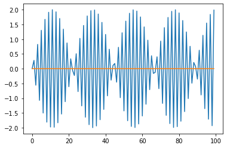

```python
sinwave_plot(a=2,k=3,
             beta=2*math.pi/3,
             sample_nb=100) # sin(3(x + 2pi/3))
```

Notice that our y axis ranges from -2 to 2 now.

Before going further let's implement how to plot 2 waves.

```python
def n_sinewave_plot(amps, periods, shifts, sample_nb, fns):
    plotable = sinMultiMap(amps, periods, shifts, sample_nb, fns)

    plt.plot(*plotable)

def double_sinewave_plot(a1: int,k1:int,beta1:int,
                    a2:int, k2:int, beta2:int, sample_nb: int):
    n_sinewave_plot([a1, a2], [k1, k2], [beta1, beta2], sample_nb,
                    [sinfn, sinfn])
```

Now let's see if we can shift sine waves

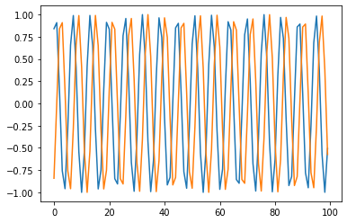

```python
double_sinewave_plot(a1=1,
                     k1=1,
                     beta1=1,
                     a2=1,
                     k2=1,
                     beta2=-1,
                     sample_nb=100)
```

As you can see beta controls the shift of sine wave.

With this we had seen the function of three major parameters of the sine wave:

**a**

is the amplitude of sine wave. It gives us how far from the zero the functions can get. It must be a positive value

**k**

is the periodicity/frequency of sine wave. It gives us how many periods are repeated within an interval of $2\pi$. The period of the curve is $2\pi/k$. It must be a positive value

**$\beta$**

is phase or phase shift of sine wave. It can be an arbitrary value

What about cosine ? Well since $\cos(x) = \sin(\frac{\pi}{2} - x)$, it basically means we shift x to the left by $\pi /2$. Let's implement this.

```python
def coswave_plot(a,k,beta, sample_nb):
    sinwave_plot(a,k,beta + math.pi/2, sample_nb)
```

```python
sinwave_plot(a=1,k=3,
             beta=2*math.pi/3,
             sample_nb=100) # sin(3(x + 2pi/3))
```

[output not shown]

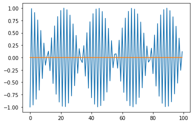

```python
coswave_plot(a=1,k=3,
             beta=2*math.pi/3,
             sample_nb=100) # cos(3(x + 2pi/3))
```

What if we want to combine these expressions ? For example add them together?

```python
def combined_sinewave_plot(amps: [int],
                           periods: [int],
                           shifts: [int],
                           sample_nb: int, fns: list):
    "plot added sine waves"
    yss = sinMultiMap(amps, periods, shifts, sample_nb, fns)
    yss = [yss[i] for i in range(len(yss)) if i % 2 != 0]
    plotable = []
    srange = list(range(sample_nb))
    for i in srange:
        counter = 0
        for k in range(len(amps)):
            counter += yss[k][i]
        plotable.append(counter)
    plt.plot(srange, plotable, # yellow dash for second sin wave
            )
```

Let's plot individual and combined sinewaves.

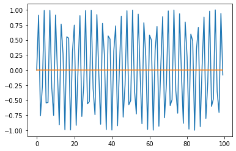

```python
sinwave_plot(a=1, k=2, beta=0, sample_nb=100)
```

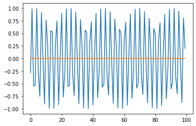

```python
sinwave_plot(a=1, k=2, beta=3, sample_nb=100)
```

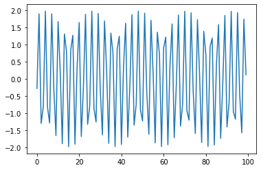

```python
combined_sinewave_plot(amps=[1,1],
                       periods=[2, 2],
                       shifts=[0, 3],
                       sample_nb=100, fns=[sinfn, sinfn])
```

What if we change the amplitude as well?

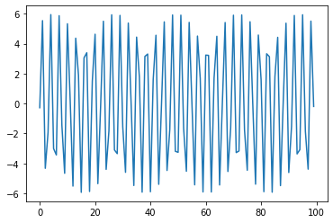

```python
combined_sinewave_plot(amps=[5,1],
                       periods=[2, 2],
                       shifts=[0, 3],
                       sample_nb=100,
                       fns=[sinfn, sinfn])
```

What if we change the frequency ?

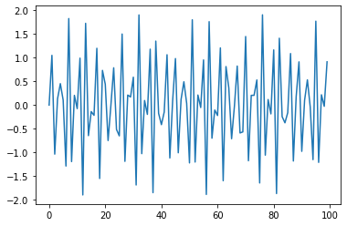

```python
combined_sinewave_plot(amps=[1,1],
                       periods=[3, 2],
                       shifts=[0, 0],
                       sample_nb=100, fns=[sinfn, sinfn])
```

This demonstration should have made it clear that for sine waves that have the same frequency addition of them produces another sine wave. However once they differ in frequency, we loose the property of obtaining a new sine wave. Of course we do not expect that you would be satisfied with simple demonstrations for the truth of that statement. You can consult (Saul 2001) p, 192 for a proof.

How about combining sine and cosine to obtain a linear combination ?

If a linear combination is $af(x) + bg(x)$ where a and b are constants, let's draw k(x) where $k(x) = 3\sin(x) + 4\cos(x)$

```python
def linear_sinwave_combination_plot(amps: [int],
                                    periods: [int],
                                    shifts: [int],
                                    fns: list,
                                    sample_nb: int,):
    if (any([a <= 0 for a  in amps]) or
        any([k <=0 for k in periods])):
        raise ValueError("all amps and shifts must be positive")
    yss = []
    xvals1 = list(range(sample_nb))
    yss = sinMultiMap(amps, periods, shifts, sample_nb, fns)
    plotable = []
    for i in range(len(xvals1)):
        counter = 0
        for k in range(len(amps)):
            counter += yss[k][i]
        plotable.append(counter)
    plt.plot(xvals1, plotable, # yellow dash for second sin wave
             xvals1, [0 for i in range(len(xvals))] # midline
            )

def cosfn(a,k, beta, t): return sinfn(a,k,beta+math.pi/2,t)
```

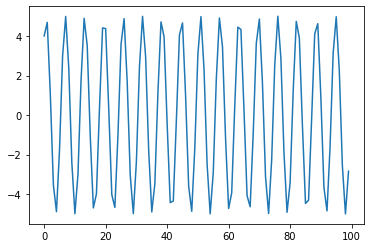

```python
combined_sinewave_plot(amps=[3, 4], periods=[1, 1],
                               shifts=[0, 0],
                               fns=[sinfn, cosfn],
                               sample_nb=100)
```

From the result, it should also be obvious that linear combination of the form $A\sin(x) + B\cos(x)$ is also a sine wave. Again the curious user can see Saul 2001, p. 190 for a proof.

Let's see what we can do with sine waves whose frequencies do not agree. Let's graph $y=x + \sin(x)$ and $y=x^2 + \cos(x)$ and lastly $y= \sin(x) + 1/3 \sin(3x)$

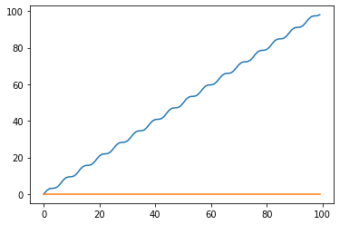

```python
def f(a,k,b,t): return t + sinfn(a,k,b,t)

sinwave_plot(a=1, k=1, beta=0,
             sample_nb=100,
             fn=f)
```

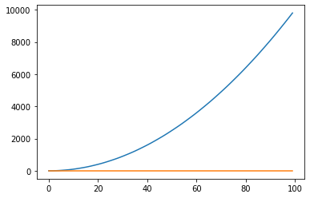

```python
# x^2 + cos(x)
sinwave_plot(a=1, k=1, beta=0,
             sample_nb=100,
             fn=lambda x,y,z,t: (t**2)+cosfn(x,y,z,t))
```

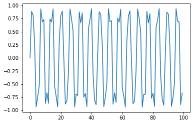

```python
#y= \sin(x) + 1/3 \sin(3x)
combined_sinewave_plot(amps=[1/3,1],
                       periods=[3, 1],
                       shifts=[0, 0],
                       sample_nb=100, fns=[sinfn, sinfn])
```

Let's make it a little more explicit what's happening here.

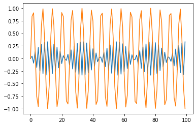

```python
# let's make whats happening a little more explicit
double_sinewave_plot(1/3, 3,0, 1,1,0, 100)
```

To put it bluntly, the sine values of the function $\sin(x)$ is disturbed by $1/3\sin(3x)$. Now let us compare three graphs: $$y = \sin(x)$$ $$y = \sin(x) + 1/3 \sin(3x)$$ $$y = \sin(x) + 1/3 \sin(3x) + 1/5 \sin(5x)$$

```python
# first one
sinwave_plot(a=1, k=1, beta=0,
             sample_nb=100)
```

[output not shown]

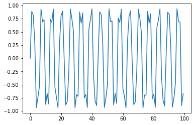

```python
# second one
combined_sinewave_plot(amps=[1/3,1],
                       periods=[3, 1],
                       shifts=[0, 0],
                       sample_nb=100, fns=[sinfn, sinfn])
```

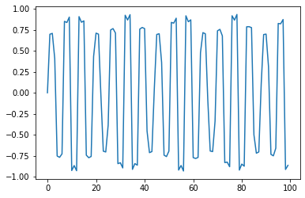

```python
# third one
combined_sinewave_plot(amps=[1,1/3, 1/5],
                       periods=[1, 3, 5],
                       shifts=[0, 0, 0],
                       sample_nb=100, fns=[sinfn, sinfn, sinfn])
```

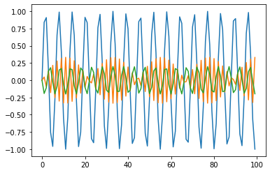

```python
# let's look at the last one more closely
n_sinewave_plot(amps=[1,1/3, 1/5],
                       periods=[1, 3, 5],
                       shifts=[0, 0, 0],
                       sample_nb=100, fns=[sinfn, sinfn, sinfn])
```

This sequence converges to a limit. In fact any periodic function, that is anything that repeats over time, can be described using the limit of the sum of sins and cosines. It is a way to approximate patterns, anything that repeats, using sine waves. This is the insight that Fourier had when he described Fourier Series and their analysis.

Formally Fourier transform of a function can be written as the following: $$\hat{f}(b) = \int_{-\infty}^{\infty}f(x) e^{-2\pi i x b}dx$$

## References

- Saul, Mark. 2001. Trigonometry. Boston.